# Introduction to Data Science Assignment Final; Harry Walters (1916 6700), Gabriel Muller

Weather predictor Recorded day to day data from the beureau of meteorology (BOM) for Whiteman Park

Our data will refined, as we have missing values

OUr data can be used to account for draughts

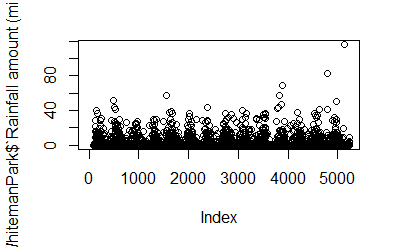

```r
# This loads the BOM data into RStudio as a .csv
# You can access the equivalent data here: http://www.bom.gov.au/jsp/ncc/cdio/weatherData/av?p_nccObsCode=136&p_display_type=dailyDataFile&p_startYear=2018&p_c=-17231830&p_stn_num=009263
library(readr)
WhitemanPark <- read_csv("C:/Users/Harry Walters/Desktop/Curtin/Year 2/Semester 1/STAT1003/Assignment/Whiteman Park Weather Data/IDCJAC0009_009263_1800_Data.csv")
plot(WhitemanPark$`Rainfall amount (millimetres)`)
```

```r
# There are 300 missing values in the data
sum(is.na(WhitemanPark$`Rainfall amount (millimetres)`))
```

```
[1] 300
```

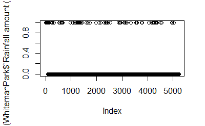

```r
# NOTE: each reading is independant of one another
plot(is.na(WhitemanPark$`Rainfall amount (millimetres)`))
```

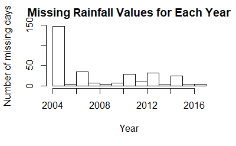

```r
# How many missing rainfall entries are there for each year?
# a histogram that finds which rainfall amounts for any year are missing
hist(WhitemanPark$Year[which(is.na(WhitemanPark$`Rainfall amount (millimetres)`)==TRUE)], main = 'Missing Rainfall Values for Each Year', xlab = 'Year', ylab = 'Number of missing days')
```

```r
table(WhitemanPark$Year[which(is.na(WhitemanPark$`Rainfall amount (millimetres)`)==TRUE)])
```

```
2004 2005 2006 2007 2008 2009 2010 2011 2012 2013 2014 2015 2016 2017
 123   24    4   34    6    4    6   28    9   31    2   24    2    3
```

From the table above, we can see that 2014 and 2016 have only 2 missing values. This large amount of data for these two years can give us a strong training and test set. We could, in theory train on the 2014 data and test on the 2016

We will now use a for loop to write the last n days of data to n columns for any given day. This will mean that our dataset will be 2n observations smaller (we are ‘chopping off’ n days from the head and tail)

The lag days can be done before cleaning the data; we can just set an NA value to the last *given* day. Alternatively, we can set the lag to NA if there isn’t a value for a previous day

```r
# Writing the year, the last n days of data, the mean of those n days, the current day, and a rain state boolean
# This part of the project is based on Workshop 10; created by Aloke
# setting the lag columns and mean to zero
# unfortunately, the lag() function doesn't pad the head and tail with NA; as it is, it has no effect on the data frame
# as a result, the lags will be written in a seperate code chunk
# Note that we can also set the repeated value to NA; rep(NA)
WP.lag <- data.frame(Year = WhitemanPark$Year, Month = WhitemanPark$Month, Day = WhitemanPark$Day, Today = WhitemanPark$`Rainfall amount (millimetres)`, Lag1 = rep(0), Lag2 = rep(0), Lag3 = rep(0), Lag4 = rep(0), Lag5 = rep(0), Lag6 = rep(0), Lag7 = rep(0), MeanLag = rep(0), MedLag = rep(0), RainState = (WhitemanPark$`Rainfall amount (millimetres)`> 0))
# updated draft version
#WP.lag <- data.frame(Year = WhitemanPark$Year, Month = WhitemanPark$Month, Day = WhitemanPark$Day, Today = WhitemanPark$`Rainfall amount (millimetres)`, Lag1 = rep(0), Lag2 = rep(0), Lag3 = rep(0), Lag4 = rep(0), Lag5 = rep(0), Lag6 = rep(0), Lag7 = rep(0), MeanLag = rep(0), MedLag = median(as.numeric(WP.lag[i,5:11]),na.rm=TRUE), RainState = (WhitemanPark$`Rainfall amount (millimetres)`> 0))
```

Note that RainState is a boolean that outputs TRUE if there has been any rain (> 0) and FALSE if not (== 0). The beaureu of meteorology (BOM) discard any readings less than 0.2mm; as moisture/humidity can give false readings.

```r
# for every entry
# write the previous entry to the current entry
#for (i in 1:7){
#  WP.lag[4+i,(i+2):nrow(WhitemanPark)] <- WhitemanPark$`Rainfall amount (millimetres)`[-i]
#}
WP.lag$Lag1[3:nrow(WhitemanPark)] <- WhitemanPark$`Rainfall amount (millimetres)`[-1]
```

```
number of items to replace is not a multiple of replacement length
```

```r
WP.lag$Lag2[4:nrow(WhitemanPark)] <- WhitemanPark$`Rainfall amount (millimetres)`[-2]
```

```
number of items to replace is not a multiple of replacement length
```

```r
WP.lag$Lag3[5:nrow(WhitemanPark)] <- WhitemanPark$`Rainfall amount (millimetres)`[-3]
```

```
number of items to replace is not a multiple of replacement length
```

```r
WP.lag$Lag4[6:nrow(WhitemanPark)] <- WhitemanPark$`Rainfall amount (millimetres)`[-4]
```

```
number of items to replace is not a multiple of replacement length
```

```r
WP.lag$Lag5[7:nrow(WhitemanPark)] <- WhitemanPark$`Rainfall amount (millimetres)`[-5]
```

```
number of items to replace is not a multiple of replacement length
```

```r
WP.lag$Lag6[8:nrow(WhitemanPark)] <- WhitemanPark$`Rainfall amount (millimetres)`[-6]
```

```
number of items to replace is not a multiple of replacement length
```

```r
WP.lag$Lag7[9:nrow(WhitemanPark)] <- WhitemanPark$`Rainfall amount (millimetres)`[-7]
```

```
number of items to replace is not a multiple of replacement length
```

```r
# The mean of the 5th to the 11th columns
# The number of missing values in a given row
# sum(is.na(WP.lag[626,3:9]))
# so to calculate the mean, we'd have 7-sum(is.na(WP.lag[626,3:9]))
# for each row in the dataset,
for (i in 1:nrow(WP.lag)){
  # divide the sum of the values in the row by the number of columns - missing columns
  #na.rm = TRUE means that NA values will be removed
  WP.lag$MeanLag[i] <- sum(WP.lag[i,5:11],na.rm = TRUE)/(7-sum(is.na(WP.lag[i,5:11])))
}
# for each row in the dataset,
for (i in 1:nrow(WP.lag)){
  sort
  # output the median of the values
  #na.rm = TRUE means that NA values will be removed
  WP.lag$MedLag[i] <- median(as.numeric(WP.lag[i,5:11]),na.rm=TRUE)
}
```

```r
# turning rainstate into factors, for the glm
WP.lag$RainState <- factor(WP.lag$RainState)
```

[figure not shown]

```r
# NOTE: IF YOU ADD MEANLAG, ALONGSIDE LAG1 TO LAG 7, IT WILL HAVE ZERO EFFECT
WP.lag.train.glm <- glm(RainState ~ Day+Lag1+Lag2+Lag3+Lag4+Lag5+Lag6+MeanLag, data = WP.lag.clean, family = binomial(logit))
WP.predict <- predict(WP.lag.train.glm, newdata = WP.lag.test, type = "response")
head(WP.predict)
```

```
        3876         4654         4051         4698         2523         1013
0.1710991963 0.2250730941 0.1247547821 0.1366170229 0.1611438472 0.1493336323
```

```r
# making predictions but with the date parameters
WP.withdates.predict <- predict(WP.lag.train.withdates.glm, newdata = WP.lag.test, type = "response")
```

```
prediction from a rank-deficient fit may be misleading
```

```r
head(WP.withdates.predict)
```

```
        3876         4654         4051         4698         2523         1013
0.1539664067 0.1885886499 0.1479245647 0.1458201708 0.1458201708 0.1803188280
```

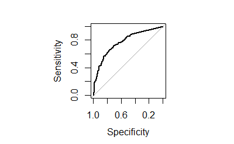

```r
# plotting ROC curve
library(pROC)
#square graph
par(pty = "s")
plot(roc(WP.lag.test$RainState, WP.withdates.predict,legacy.axes = TRUE))
```

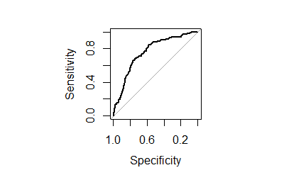

```r
# using just the date to predict the next day of rain
WP.lag.train.glm.version2 <- glm(RainState ~ Month+Day, data = WP.lag.train, family = binomial(logit))
WP.withdates.predict.version2 <- predict(WP.lag.train.glm.version2, newdata = WP.lag.test, type = "response")
# plotting ROC curve
library(pROC)
#square graph
par(pty = "s")
plot(roc(WP.lag.test$RainState, WP.withdates.predict.version2,legacy.axes = TRUE))
```

```r
table(WP.withdates.predict.class, WP.lag.test$RainState)
```

```
WP.withdates.predict.class FALSE TRUE
                   No Rain    24    5
                   Rain       12   40
```

```r
# neuralnet
# USING A NEURAL NETWORK WITH MULTIPLE HIDDEN LAYERS
library(neuralnet)
# ONLY USING THE LAST 7 DAYS

# our x are the 5th to 11th elements (the last 7 days)
# our y is the 4th element (today's weather)

#WP.nnet <- nnet(x = WP.lag.2014[,5:11], y = WP.lag.2014[,4],formula = RainState ~ Lag1+Lag2+Lag3+Lag4+Lag5+Lag6+Lag7,size = 1, maxit=1, data=WP.lag.2014)


# AS WE ARE USING A NEURAL NETWORK, I AM ATTEMPTING TO PREDICT THE NUMERICAL RAINFALL, RATHER THAN A BINARY STATE

# WP.nnet <- nnet(Today ~ Lag1+Lag2+Lag3+Lag4+Lag5+Lag6+Lag7,size = 5, maxit=10000, data=WP.lag.2014)

# rep (amount of times we repeat the training process) is very important! It means that we get consistant results


#Training for the neural net
WP.lag.2014 <- WP.lag.clean[which(WP.lag.clean$Year == 2014),]
# QUICK EDA
# these are the rows which have an NA VALUE FOR 'TODAY'
#WP.lag.2014 <- WP.lag.2014[-which(is.na(WP.lag.2014$Today)),]
# Test
WP.lag.2016 <- WP.lag.clean[which(WP.lag.clean$Year == 2016),]
#WP.lag.2016 <- WP.lag.2016[-which(is.na(WP.lag.2016$Today)),]

# converting the training and test 'date' parameters from an integer to a double
WP.lag.2014$Day <- as.double(WP.lag.2014$Day)
WP.lag.2014$Month <- as.double(WP.lag.2014$Month)

WP.lag.2016$Day <- as.double(WP.lag.2016$Day)
WP.lag.2016$Month <- as.double(WP.lag.2016$Month)

WP.neuralnet <- neuralnet(Today ~ Month+Day+Lag1+Lag2+Lag3+Lag4+Lag5+Lag6+Lag7+MeanLag+MedLag,data=WP.lag.2014,hidden = 2,stepmax=3e+05,rep=6)
plot(WP.neuralnet)


# computes the outputs of all neurons for specific (covariate)? vectors for a trained network
WP.neuralnet.predict <- compute(WP.neuralnet, WP.lag.2016[,c(2,3,5:13)])$net.result
hist(WP.neuralnet.predict)
#compute(WP.neuralnet, WP.lag.2016[,5:12])$net.result

WP.neuralnet.class <- rep("Non-Rain", length(WP.neuralnet.predict))
table(WP.neuralnet.predict)
WP.neuralnet.class[WP.neuralnet.predict > 0] <- "Rain"
#WP.neuralnet.predict

# This method is 10 percent less accurate at predicing when it will rain
# It predicts that it will rain with ~60-68% accuracy
# as the number of hidden layers increases, the accuracy of predicting rainfall decreases.
# The number of predicted non-rainy days stays at around 78% accuracy

# THE PROBLEM IS that we are using only one hidden layer
# more hidden layers will improve generalisation, in theory?
# keep in mind, sinceour output is numerical (non-binary), our confusion matrix will look silly
table(table(WP.neuralnet.class,WP.lag.2016$Today))
plot(table(WP.neuralnet.class, WP.lag.2016$Today))

plot(WP.lag.2016$Today-compute(WP.neuralnet,covariate = WP.lag.2016[,c(2,3,5:13)])$net.result,main="Residual Plot of Actual and Predicted (closer to 0 is better)", xlab="Day Number",ylab="Actual-Predicted")
```

[output not shown]

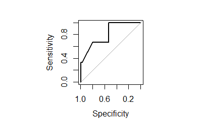

```r
# plotting ROC curve
library(pROC)
#square graph
par(pty = "s")
plot(roc(WP.lag.2016$Today, WP.neuralnet.predict,legacy.axes = TRUE))
```

[figure not shown]

[figure not shown]

```r
# quick glm plot attempt

# maybe I could do:
# data = WP.lag[which(WP.lag$Year == 2014),]
levels(WP.lag$RainState)
summary(glm(RainState ~ Lag1 + Lag2 + Lag3 + Lag4 + Lag5 + Lag6 + Lag7 + MeanLag, data = WP.lag, family = binomial(logit)))
summary(glm(RainState ~ Lag1 + Lag2 + Lag3 + Lag4 + Lag5 + Lag6 + Lag7 + MeanLag, data = WP.lag.clean, family = binomial(logit)))
```

[output not shown]

# IMPORTANT

We can use tapply to calcualte the mean rainfall of the previous n days

```r
# WP.lag$LagMean <- tapply(Lag1:Lag5, mean)
```